# SSB: analyse av innvandrere i 2022

Lalita Thorbjørnsen

28.02.2024

# Abstrakt

2022 var et år preget av store kriser som påvirket verdenssamfunnet og Norge. Ved inngangen til året, var Norge fortsatt preget av koronapandemien[^1].

Russlands invasjon av Ukraina har hatt innvirkning på tallene som kommer frem i inntekts- og formuesstatistikken i 2022. Det medførte til at innvandrere fra Ukraina var overrepresentert i lavinntektsgruppen, der rundt 82 prosent hadde lavinntekt. De fleste av ukrainere som kom til Norge i 2022 hadde ikke et fullt inntektsår. Dermed vil inntekten til denne gruppen være svært lave.

## 1. Innledningen

Analysen presenterer den økonomiske situasjonen til innvandrere i 2022 med tall fra inntekts- og formuesstatistikken for husholdninger, som en del av praksisen min av ECON-4032 Internship i økonomi. Rapporten går blant annet gjennon lavinntektsgrensen og andelen for 2022, medianinntekten, inntekfsfordelingen av kjønn, yrkestilknytning, botid og yrkesinntekt for innvandrere, Rapporten bruker relativ tilnærming som et mål for lavinnteksgrensen.

## 1.1 Datagrunnlaget

Datagrunnlaget til tallene om inntekt og formue er hentet fra Statistisk sentralbyrås (SSB) inntekts- og formuesstatistikk for husholdninger. Inntektsopplysninger påkobles fra ulike administrative registre, blant annet Skattedirektoratet, NAV, Husbanken og Lånekassen. Husholdningssammensetning er avledet ved hjelp av ulike kilder som Det sentrale folkeregister (DSF), Lånekassen, Postens adresseregister og opplysninger fra skattemeldingen.

## 1.2 Forklaring av begreper

Jeg vil først begynne med å forklare noen viktige begreper.

**Medianinntekt:**

Medianinntekten er definert som den inntekten på midten etter å sortert fra lavest til høyest. Medianinntekten foretrekkes ofte som en indikator i stedet for gjennomsnittsinntekt, siden den ikke påvirkes av ekstreme verdier som kan oppstå ved beregning av gjennomsnittsinntekten.

**Inntekt etter skatt per forbruksenhet**

I denne rapporten benyttes begrepet *inntekt etter skatt* som et mål på inntekt. Begrepet omfatter summen av alle yrkesinntekter (lønn- og næringsinntekter), kapitalinntekter (renteinntekter av bankinnskudd og avkastning på diverse verdipapirer). Til fratrekk kommer utlignet skatt (sum inntekts- og formuesskatt til kommune, fylke og stat, samt medlemsavgifter til folketrygden) og negative overføringer (det vil si pensjonspremier i arbeidsforhold og betalt barnebidrag).

Hvis man ønsker å måle inntektsnivået til en enkeltperson, er det naturlig å ta utgangspunkt i den samlede inntekten til husholdningen personen tilhører. En husholdning består av én eller flere personer med ulikt inntektsnivå. I mange husholdninger bor det i tillegg barn eller andre personer som ikke har egen inntekt, men som blir forsørget av de andre husholdningsmedlemmene. En person som har lav eller ingen egen inntekt, kan fortsatt ha et høyt inntektsnivå, avhengig av inntektene til de andre husholdningsmedlemmene. Dersom vi skal se ppå enkeltpersoner er normalt å bruke inntekt per forbruksenhet

Inntekt per forbruksenhet beregnes ved å dele husholdningens samlede inntekt etter skatt på forbruksveksten. Forbruksvekten beregnes slik at første voksne husholdningsmedlem får vekt lik 1,0, mens neste voksne får vekt lik 0,5 og alle barn vekt lik 0,3. Etter denne ekvivalensskalaen trenger derfor en familie på to voksne og to barn en samlet inntekt etter skatt tilsvarende 2,1 ganger inntekten til en aleneboende for å ha samme levestandard.

**Lavinntekt:**

Det finnes ingen konkret eller en universal definisjon på fattigdom, men lavinntekt en av flere indiktator som brukes. Lavinntektt er basert på enten en *absolutt tilnærming* eller *relafiv tilnærming*. I *Økonomi og levekår for lavinntekstgrupper 202*0 definerer Hattrem *absolutt tilnætming* og *relativ tilnærming* som; I en *absolutt tilnærming t*ar man utgangspunkt i det pengebeløpet som kreves for å skaffe seg et utvalg av basisvarer, for eksempel matvarer som regnes som ernæringsmessig nødvendig. Det blir også gjort tillegg for nødvendige utgifter til husleie, klær mv. Det mest kjente eksemplet på en absolutt definisjon av lavinntekt er den amerikanske fattigdomsgrensen. Den ble utviklet tidlig på 1960-tallet og tok utgangspunkt i det gjennomsnittlige inntektsnivået til en husholdning med to barn som brukte 30 prosent eller mer av det totale forbruket på matvarer (Dalaker, 2000). En slik lavinntektsgrense skal i utgangspunktet være absolutt, dvs. at dette beløpet bare skal justeres hvert år for prisstigning. Imidlertid vil det også her foreligge et subjektivt element. Varer som tidligere ble betraktet som luksus, kan i dag bli regnet som nødvendighetsartikler. Telefon, TV og internettilknytning kan være eksempler på slike varer og tjenester. Den amerikanske fattigdomsgrensen har blant annet blitt kritisert for at den ikke tar hensyn til at forbruksmønsteret har endret seg over tid, og for at den i stor grad gjenspeiler forbruksmønsteret slik det var i 1950-tallets USA (Citro & Micheal, 1995).

I en *relativ tilnærming* unngår man å måtte foreta subjektive valg vedrørende hvilke nødvendighetsartikler som skal inngå i beregningen av lavinntektsgrensen. I denne metoden er det vanlig å benytte det generelle inntektsnivået i landet som referanse. Man tar da ofte utgangspunkt i medianinntekten for hele befolkningen.

SSB benytter som regel 60 EU-skalaen, som definerer 60 prosent av medianinntekten etter skatt per forbruksenhet som lavinntektsgrensen. Med andre ord, har en person lavinntekt dersom vedkommende har en inntekt etter skatt per forbruksenhet som tilsvarer 60 prosent eller mindre av medianinntekten i befolkningen, etter skatt og per forbruksenhet[^2].

## 2. Deskriptiv data

Rapporten tar i bruk deskriptiv data som en første tilnærming til å utforske datasettet. Deskriptiv data, også kjent som beskrivende data, gir et grunnleggende innsyn i egenskapene til datasettet, noe som er avgjørende for å bygge en solid forståelse av dataene. I tillegg til å gi et overblikk, fungerer deskriptiv data også som et verktøy for kvalitetskontroll av dataene. Ved å undersøke sentrale statistikker og visuelle representasjoner, kan man oppdage eventuelle feil som kan påvirke påliteligheten og gyldigheten til analysene.

## 2.1 Demografi

Vi begynner med å utforske demografiske trekk i datasettet. Dette inkluderer informasjon om befolkningssammensetningen, kjønnsfordelingen og gjennomsnittsalderen.

### 2.1.1 Befolkningen

Befolkningssammensetningen viser et totalt antall på 5 455 076 personer i 2022, hvor majporiteten er norske. Blandt andre grupper, var det 1 043 720 innvandrere og 63 838 norskfødte med innvandreforeldre. Fokuset i denne rapporten vil primært være rettet mot innvandrere og norskfødte med innvandrerforeldre..

| Antall personer i ulike grupper i befolkningen | Antall personer i ulike grupper i befolkningen Antall personer |
| --- | --- |
| Hele Befolkningen | 5455076 |
| Født i Norge med to norskfødte foreldre | 4088312 |
| Innvandrere | 1043720 |
| Norskfødte med innvandrerforeldre | 63838 |
| Utenlandsfødte med én norskfødt forelder | 33580 |
| Norskfødte med én utenlandsfødt forelder | 184886 |
| Utenlandsfødte med to norskfødte foreldre | 40740 |

### 2.1.2 Kjønn

I kjønnsfordelingen viser grafen en overrepresentasjon av kvinner med lavinntekt, spesielt i inntektsintervallene fra 100 000 til 300 000. På den annen side er menn overrepresentert i de høyeste og laveste inntektsområdene. Dersom vi analyserer grafen som viser kjønnsfordelingen, blir det tydelig at fordelingen mellom kvinner og menn er relativt lik.

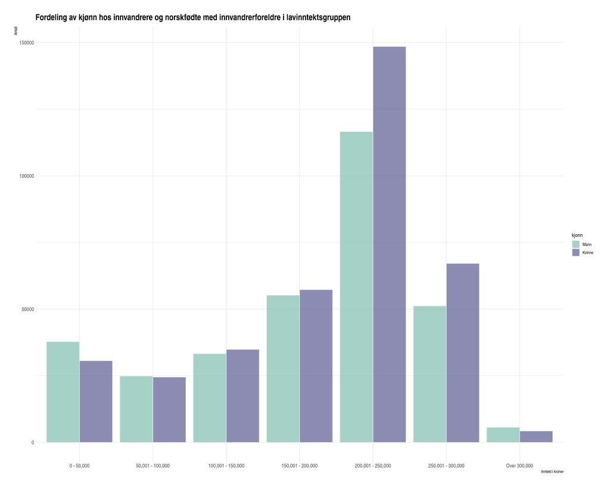

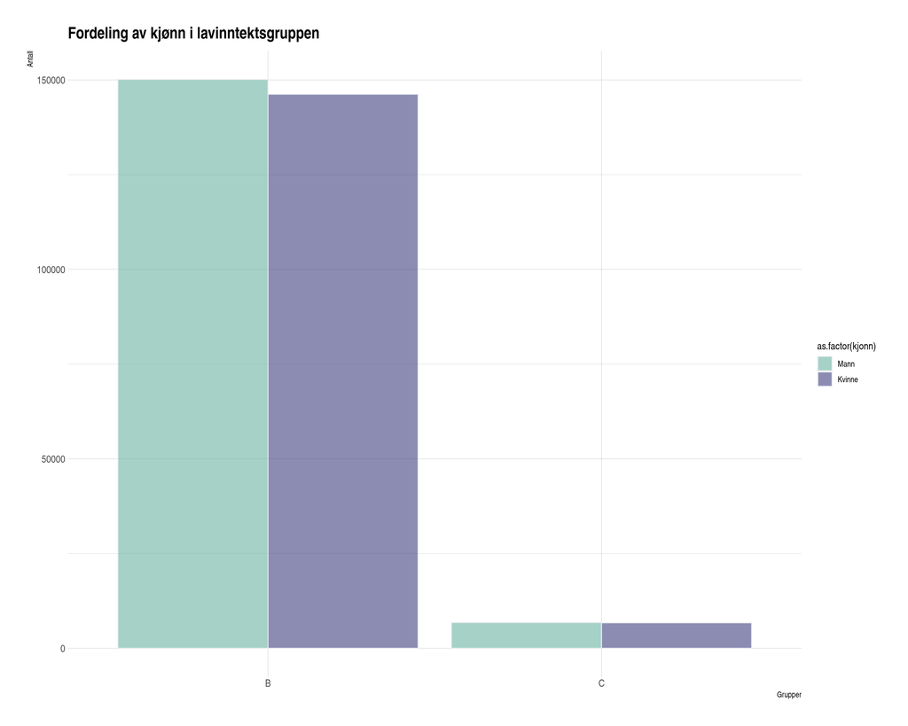

### 2.1.3 Alder

Gjennomsnittsalderen for hele befolkningen ligger litt over 51,5 år. Den reduseres betydelig til 43 år blant innvandrere og til 33 år blant norskfødte med innvandrerforeldre.

| Alder hos utvalgte grupper Kategori | Alder hos utvalgte grupper Gjennomsnittsalder |
| --- | --- |
| Hele befolkningen | 51.6 |
| Innvandrere | 43.7 |
| Norskfødte med innvandrerforeldre | 33.7 |

## 2.2 Inntekt

Grafen viser at flertallet har mellom 300 000 - 350 000 kr.

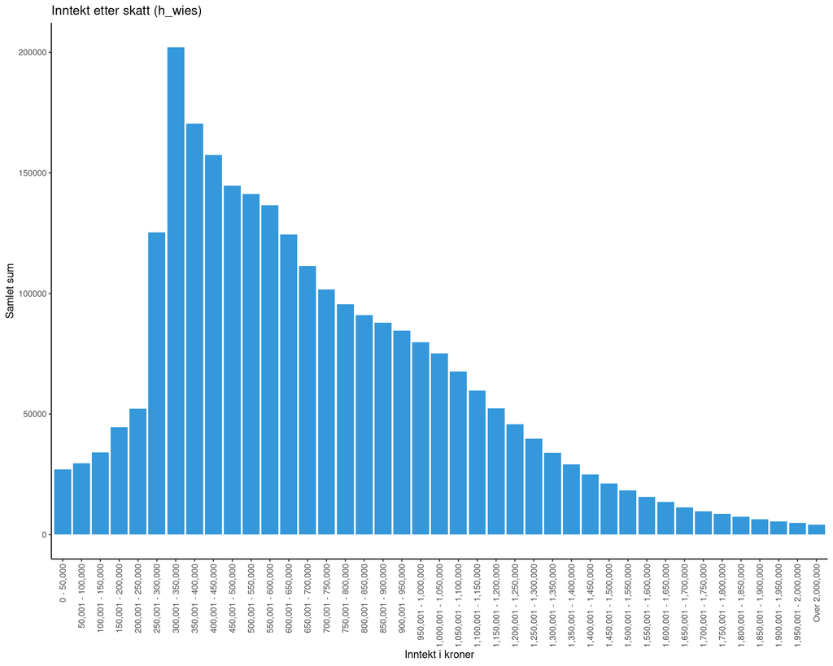

## 2.3 Medianinntekt og lavinntektsgrense samt andre indikatorer

Medianinntekten i 2022 per forbruksenhet etter skatt var 441 352 kr. Det vil si når inntekt blir sortert fra lavest til høyest, så vil den inntekten i midten være 441 352 kr.

**Prosentvis andel og antall med lavinntekt (EU-skala 60) 2022**

|  | Hele befolkningen med studentshusholdninger | Verdier |
| --- | --- | --- |
| Andel med lavinntekt i prosent | Andel med lavinntekt i prosent | 12.68 |
| Antall personer med lavinntekt | Antall personer med lavinntekt | 691814.00 |

### 2.3.1 Inntektsfordeling av grupper med lavinntekt

Vi ser at gruppe A: norskfødte med to norske foreldre og B: innvandrere er de to største gruppene for de med lavinntekt.

Grafen nedenfor viser fordeling av inntekt i ulike grupper som har lavinntekt.

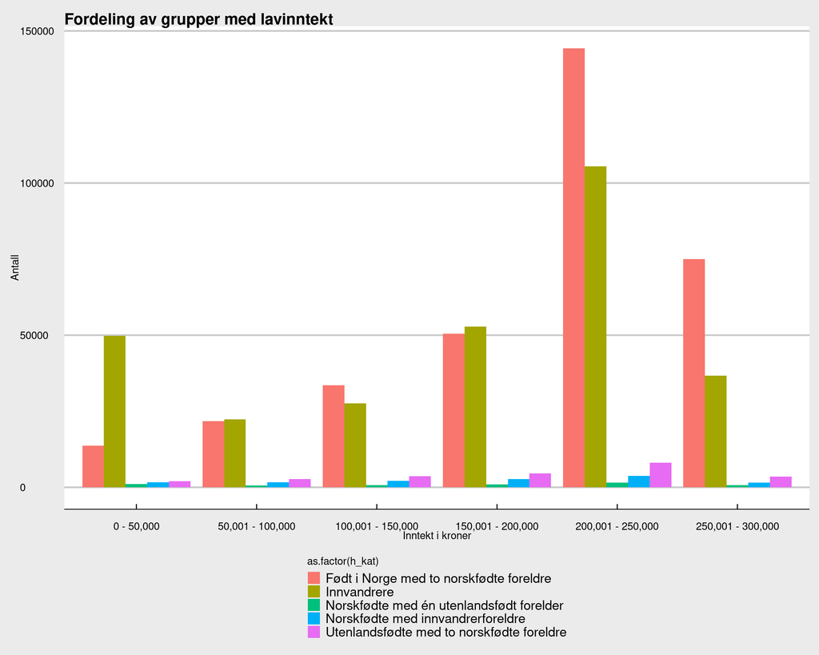

### 2.3.2 Innvandrere og norskfødte med innvandrerforeldre

Vi observerer betydelige forskjeller i antallet mellom gruppene. Videre bemerker vi at begge gruppene har størst antall observasjoner innenfor inntektsintervallet 200 000 - 250 000. Det er lavere enn lavinntektsgrensen.

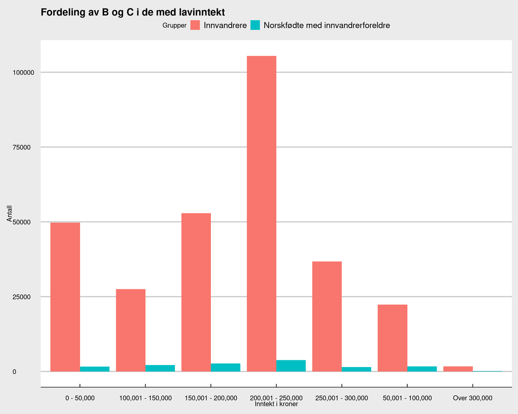

### 2.3.3 Yrkestilknytning

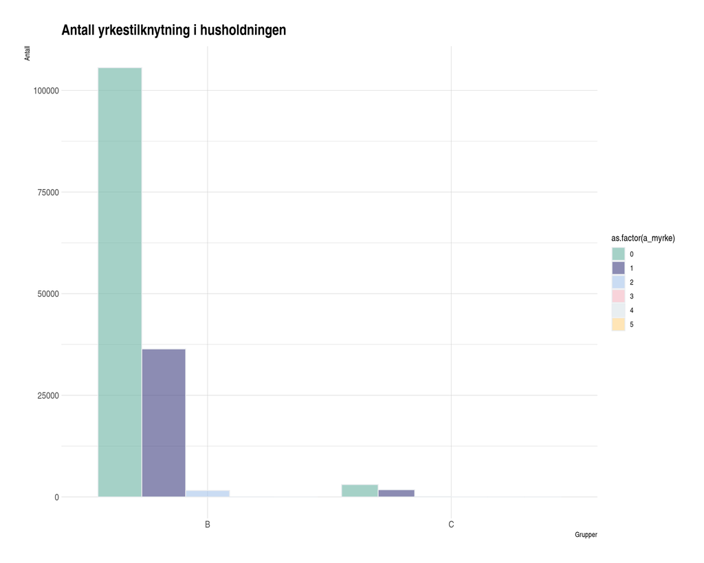

### 2.3.4 Tabell med innvandrere og norskfødte med innvandrerforeldre i lavinntektsgruppen

| Antall personer med yrkestilknytning i husholdningen for gruppe B: innvandrere Yrkestilknytning | Antall personer med yrkestilknytning i husholdningen for gruppe B: innvandrere Antall | Antall personer med yrkestilknytning i husholdningen for gruppe B: innvandrere Prosent |
| --- | --- | --- |
| 0 | 178588 | 64.32 |
| 1 | 91405 | 32.92 |
| 2 eller mer | 7644 | 2.75 |

| Antall personer med yrkestilknytning i husholdningen for gruppe C: norskfødte med innvandrerforeldre Yrkestilknytning | Antall personer med yrkestilknytning i husholdningen for gruppe C: norskfødte med innvandrerforeldre Antall | Antall personer med yrkestilknytning i husholdningen for gruppe C: norskfødte med innvandrerforeldre Prosent |
| --- | --- | --- |
| 0 | 4309 | 52.65 |
| 1 | 3523 | 43.05 |
| 2 eller mer | 352 | 4.30 |

### 2.3.5 Husholdninger

Dersom vi ser på ulike husholdningstyper for hele befolkningen, har aleneboende størst andel med lavinntekt med 24.6 prosent. Dette tilsvarer hver fjerde aleneboende har lavinntekt. Rett etter kommer mor eller far med barn med andelen 22.5 prosent. Dette tilsvarer litt mer enn hver femte person som er mor eller far med barn har lavinntekt. På den andre siden, har par med barn og par uten barn lavest andel med lavinntekt.

Videre har vi husholdningstypene hos innvandrere hvor andelene med lavinntekt øker mye. Mor eller far med barn har høyest andel med 46 prosent. Nesten hver anrdre person som tilhører denne husholdningstypen har lavinntekt. Etter kommer aleneboende med 40.8 prosent. Lavest andel med lavinntekt er par uten barn med 15.9 prosent.

Norskfødte med innvandrerforeldre følger den samme tendensen som resten av befolkningen, der andelen aleneboende er høyest og andelen par uten barn er lavest.

| Husholdningstyper Husholdningstype | Husholdningstyper Totalt antall hele befolkningen | Husholdningstyper Antall lavinntekt | Husholdningstyper Prosent |
| --- | --- | --- | --- |
| aleneboende | 1058029 | 260317 | 24.60 |
| flerfamiliehusholdninger | 309039 | 33097 | 10.71 |
| mor eller far med barn | 416353 | 93861 | 22.54 |
| par med barn | 2324470 | 148077 | 6.37 |
| par uten barn | 1232730 | 45676 | 3.71 |

| Husholdningstyper innvandrere Husholdningstype | Husholdningstyper innvandrere Totalt antall hele befolkningen | Husholdningstyper innvandrere Antall lavinntekt | Husholdningstyper innvandrere Prosent |
| --- | --- | --- | --- |
| aleneboende | 214601 | 87618 | 40.83 |
| flerfamiliehusholdninger | 78334 | 19788 | 25.26 |
| mor eller far med barn | 94832 | 43665 | 46.04 |
| par med barn | 506009 | 106018 | 20.95 |
| par uten barn | 129610 | 20548 | 15.85 |

| Husholdningstyper norskfødte med innvandrerforeldre Husholdningstype | Husholdningstyper norskfødte med innvandrerforeldre Totalt antall hele befolkningen | Husholdningstyper norskfødte med innvandrerforeldre Antall lavinntekt | Husholdningstyper norskfødte med innvandrerforeldre Prosent |
| --- | --- | --- | --- |
| aleneboende | 10299 | 3458 | 33.58 |
| flerfamiliehusholdninger | 10293 | 1016 | 9.87 |
| mor eller far med barn | 4884 | 1121 | 22.95 |
| par med barn | 26474 | 2167 | 8.19 |
| par uten barn | 6488 | 422 | 6.50 |

### 2.3.6 Lavinntekt etter landbakgrunn

Andelene med lavinntekt varierer mye etter hvilke verdensdeler man har bakgrunn fra og lengde på botid i Norge. Det er store variasjoner i andel med lavinntekt etter landbakgrunn blandt innvandrere og norskfødte med innvandrerforeldre.

Norskfødte med innvandrerforeldre består av relaltiv få personer. I prosentandelen har Somalia høyest andel med lavinntekt. Men dersom vi ser på den største gruppen, så er Pakistan soleklar den største med 13.7 prosent.

#### Tabell: Innvandrere og norskfødte med innvandrerforeldre

| Innvandring samlet Land | Innvandring samlet EU eller EØS status | Innvandring samlet Totalt antall | Innvandring samlet Antall lavinntekt | Innvandring samlet Prosent |
| --- | --- | --- | --- | --- |
| Totalt |  | 947426 | 250039 | NA |
| Ukraina | 0 | 31519 | 25679 | 81.47 |
| Kongo | 0 | 7299 | 4336 | 59.41 |
| Syria | 0 | 40778 | 23107 | 56.67 |
| Somalia | 0 | 41595 | 22331 | 53.69 |
| Sudan | 0 | 6018 | 2985 | 49.60 |
| Irak | 0 | 35270 | 12276 | 34.81 |
| Afghanistan | 0 | 25036 | 8419 | 33.63 |
| Eritrea | 0 | 32646 | 10886 | 33.35 |
| Bulgaria | 1 | 8537 | 2649 | 31.03 |
| Russland | 0 | 22859 | 6830 | 29.88 |
| Etiopia | 0 | 12238 | 3650 | 29.83 |
| Marokko | 0 | 11755 | 3370 | 28.67 |
| Kina | 0 | 11291 | 3013 | 26.68 |
| Brasil | 0 | 5219 | 1392 | 26.67 |
| Latvia | 1 | 13859 | 3439 | 24.81 |
| Romania | 1 | 19706 | 4881 | 24.77 |
| Pakistan | 0 | 48432 | 11503 | 23.75 |
| Iran | 0 | 25243 | 5977 | 23.68 |
| Spania | 1 | 8148 | 1898 | 23.29 |
| Tyrkia | 0 | 23329 | 5303 | 22.73 |
| Thailand | 0 | 14833 | 3316 | 22.36 |
| USA | 1 | 10272 | 2138 | 20.81 |
| Frankrike | 1 | 7933 | 1638 | 20.65 |
| Italia | 1 | 6142 | 1242 | 20.22 |
| Litauen | 1 | 49383 | 9804 | 19.85 |
| Polen | 1 | 121777 | 23651 | 19.42 |
| Chile | 0 | 8867 | 1653 | 18.64 |
| Filippinene | 0 | 23508 | 4207 | 17.90 |
| Kosovo | 0 | 17959 | 3212 | 17.89 |
| Vietnam | 0 | 24382 | 4069 | 16.69 |
| Finland | 1 | 7663 | 1271 | 16.59 |
| Tyskland | 1 | 32115 | 5296 | 16.49 |
| Nord-Makedonia | 0 | 5240 | 839 | 16.01 |
| Bosnia-Hercegovina | 0 | 19980 | 3103 | 15.53 |
| Kroatia | 1 | 7391 | 1116 | 15.10 |
| Nederland | 1 | 10650 | 1586 | 14.89 |
| India | 0 | 23034 | 3292 | 14.29 |
| Sri Lanka | 0 | 16107 | 2179 | 13.53 |
| Storbritannia | 1 | 19777 | 2601 | 13.15 |
| Serbia | 0 | 9824 | 1257 | 12.80 |
| Island | 1 | 8226 | 1042 | 12.67 |
| Danmark | 1 | 24714 | 2917 | 11.80 |
| Sverige | 1 | 46872 | 4686 | 10.00 |

#### Tabell: Innvandrere

| Innvandrere Land | Innvandrere EU eller EØS status | Innvandrere Totalt antall | Innvandrere Antall lavinntekt | Innvandrere Prosent |
| --- | --- | --- | --- | --- |
| Ukraina | 0 | 31496 | 25670 | 81.50 |
| Kongo | 0 | 7240 | 4322 | 59.70 |
| Syria | 0 | 40417 | 23035 | 56.99 |
| Somalia | 0 | 40045 | 21728 | 54.26 |
| Sudan | 0 | 5998 | 2977 | 49.63 |
| Irak | 0 | 33962 | 11865 | 34.94 |
| Afghanistan | 0 | 24851 | 8382 | 33.73 |
| Eritrea | 0 | 32225 | 10811 | 33.55 |
| Marokko | 0 | 8967 | 2877 | 32.08 |
| Bulgaria | 1 | 8510 | 2642 | 31.05 |
| Etiopia | 0 | 12050 | 3610 | 29.96 |
| Russland | 0 | 22771 | 6800 | 29.86 |
| Pakistan | 0 | 31915 | 9225 | 28.90 |
| Kina | 0 | 10700 | 2938 | 27.46 |
| Brasil | 0 | 5189 | 1381 | 26.61 |
| Tyrkia | 0 | 18580 | 4723 | 25.42 |
| Romania | 1 | 19624 | 4874 | 24.84 |
| Latvia | 1 | 13839 | 3431 | 24.79 |
| Iran | 0 | 24081 | 5753 | 23.89 |
| Spania | 1 | 8014 | 1888 | 23.56 |
| Thailand | 0 | 14681 | 3278 | 22.33 |
| USA | 1 | 9802 | 2086 | 21.28 |
| Frankrike | 1 | 7834 | 1619 | 20.67 |
| Italia | 1 | 6049 | 1222 | 20.20 |
| Litauen | 1 | 49378 | 9803 | 19.85 |
| Polen | 1 | 120967 | 23584 | 19.50 |
| Chile | 0 | 7511 | 1446 | 19.25 |
| Vietnam | 0 | 19185 | 3572 | 18.62 |
| Kosovo | 0 | 16456 | 3005 | 18.26 |
| Filippinene | 0 | 22602 | 4109 | 18.18 |
| Finland | 1 | 7302 | 1218 | 16.68 |
| Tyskland | 1 | 31509 | 5241 | 16.63 |
| Bosnia-Hercegovina | 0 | 18730 | 2950 | 15.75 |
| Kroatia | 1 | 6993 | 1088 | 15.56 |
| Nederland | 1 | 10151 | 1540 | 15.17 |
| India | 0 | 20606 | 3122 | 15.15 |
| Sri Lanka | 0 | 13518 | 1933 | 14.30 |
| Storbritannia | 1 | 19121 | 2527 | 13.22 |
| Serbia | 0 | 9458 | 1234 | 13.05 |
| Island | 1 | 7922 | 995 | 12.56 |
| Danmark | 1 | 23067 | 2798 | 12.13 |
| Sverige | 1 | 45931 | 4537 | 9.88 |

#### Tabell: Norskfødte med innvandrerforeldre

| Norskfødte med innvandrerforeldre Land | Norskfødte med innvandrerforeldre EU eller EØS status | Norskfødte med innvandrerforeldre Totalt antall | Norskfødte med innvandrerforeldre Antall lavinntekt | Norskfødte med innvandrerforeldre Prosent |
| --- | --- | --- | --- | --- |
| Somalia | 0 | 1550 | 603 | 38.90 |
| Irak | 0 | 1308 | 411 | 31.42 |
| Iran | 0 | 1162 | 224 | 19.28 |
| Marokko | 0 | 2788 | 493 | 17.68 |
| Chile | 0 | 1356 | 207 | 15.27 |
| Pakistan | 0 | 16517 | 2278 | 13.79 |
| Kosovo | 0 | 1503 | 207 | 13.77 |
| Bosnia-Hercegovina | 0 | 1250 | 153 | 12.24 |
| Tyrkia | 0 | 4749 | 580 | 12.21 |
| Vietnam | 0 | 5197 | 497 | 9.56 |
| Sri Lanka | 0 | 2589 | 246 | 9.50 |
| Danmark | 1 | 1647 | 119 | 7.23 |
| India | 0 | 2428 | 170 | 7.00 |

### 2.3.9 Botid

Hvor lenge hovedinntektstakeren har bodd i Norge kan være en viktig faktor for å forstå andelen med lavinntekt blant innvandrerhusholdninger. Vanligvis har personer med kort botid lavere inntekter, da de ofte har en svakere tilknytning til arbeidsmarkedet og har hatt mindre tid til å opparbeide seg rettigheter til ulike stønader.

Grafene fremviser sammenhengen mellom lengden på botiden i Norge og prosentandelen av befolkningen med lavinntekt. Som det fremgår av grafene, reduseres prosentandelen av personer med lavinntekt etter hvert som lengden på botiden i Norge øker. Dette antyder at det er en negativ sammenheng mellom lengden på botiden og forekomsten av lavinntekt. På grunn av den negative sammenhengen mellom lengden på botiden og forekomsten av lavinntekt, indikerer dette at personer som har bodd i Norge over lengre tid, har en tendens til å bli bedre integrert i samfunnet og har dermed lavere risiko for å oppleve lavinntekt.

#### Botid: Innvandrere fra EU/EØS, Sveits, USA, Canada, Australia og New Zealand, etter hovedinntektstakers botid i Norge

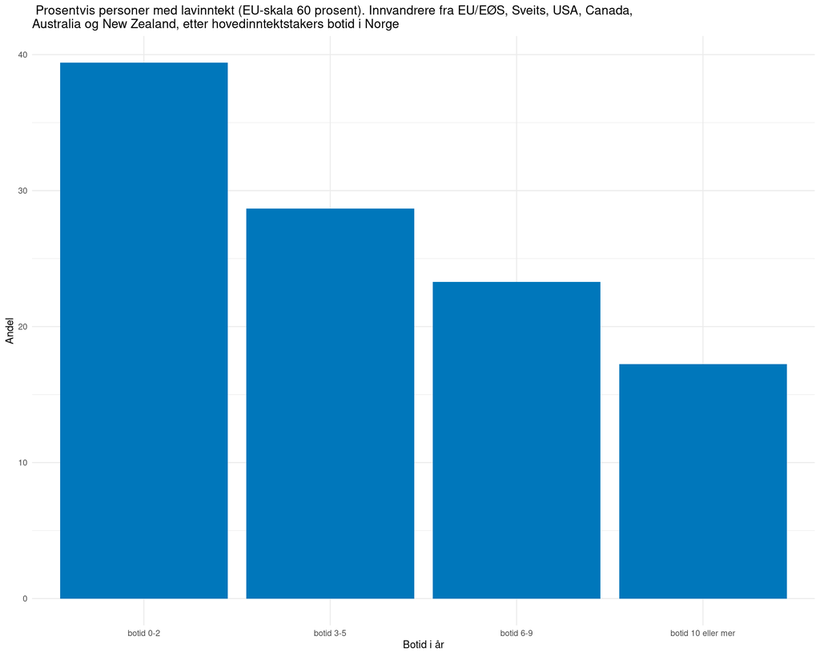

#### Botid: Innvandrere fra Afrika, Asia, Latin-Amerika, Europa utenom EU/EØS og Oseania utenom Australia og New Zealand, etter hovedinntektstakers botid i Norge

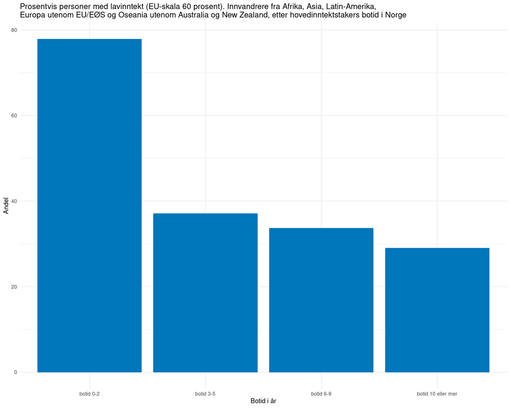

### 2.3.10 Yrkesinntekt som den største inntektskilden

Grafen viser det er størst andel personer som tilhører en husholdning der yrkesinntekt (lønn og næringsinntekt) er største inntektskilde i ulike grupper. Det vil si at mange av de har yrkestilknytning.

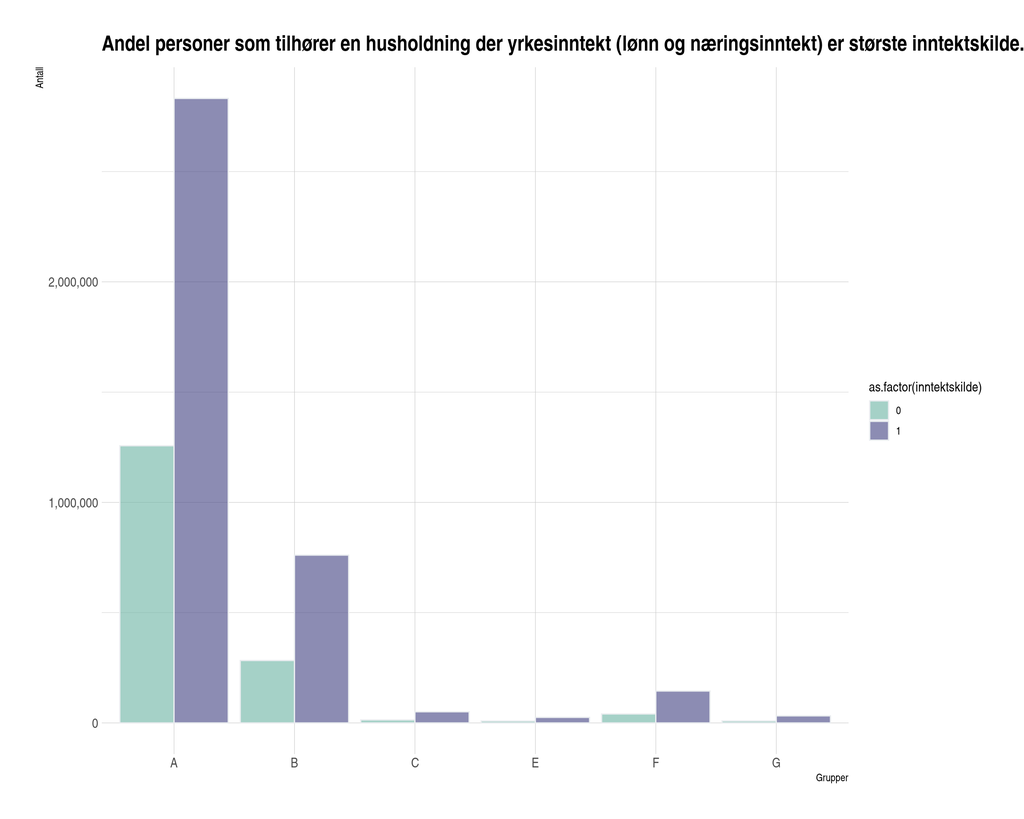

#### Tabell:

| Antall personer som tilhører en husholdning der yrkesinntekt er største inntektskilde, fordelt på grupper h_kat | Antall personer som tilhører en husholdning der yrkesinntekt er største inntektskilde, fordelt på grupper 0 | Antall personer som tilhører en husholdning der yrkesinntekt er største inntektskilde, fordelt på grupper 1 |
| --- | --- | --- |
| A | 1256655 | 2831657 |
| B | 282930 | 760790 |
| C | 13485 | 50353 |
| E | 8653 | 24927 |
| F | 40427 | 144459 |
| G | 8931 | 31809 |

### 2.3.11 Yrkesinntekt som den største inntektskilden

Det kommer tydeligere fram i grafen under. 70.5 prosent i hele befolkningen har yrkesinntekt som den største inntektskilden. 29.5 har andre inntekt som den største inntektskilden. Andre inntekt kan være overføringer fra staten.

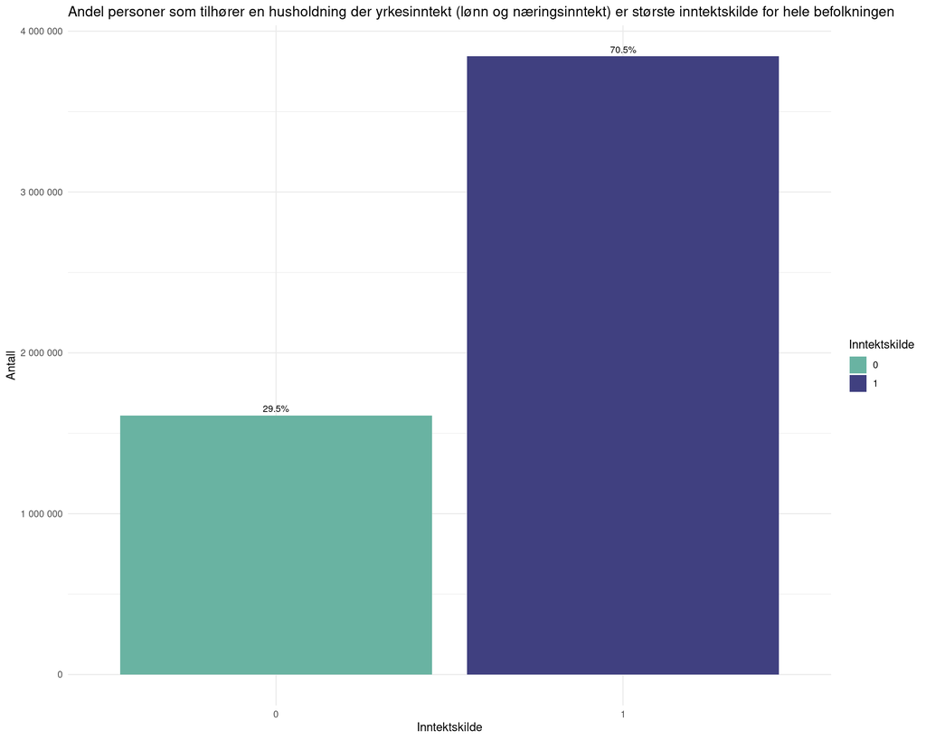

Antall personer med yrkesinntekt som den største inntektskilde for hele befolkningen

| inntektskilde | Antall personer | Prosentandel |
| --- | --- | --- |
| 0 | 1611125 | 29.53418 |
| 1 | 3843995 | 70.46582 |

Dersom vi ser på de med lavinntekt, er det flest andel med 58.8 prosent som ikke har yrkesinntekt som den største inntektskilden. Dette kan tyde på at de mottar stønader eller økonomisk bistand for den økonomiske belastningen som lavinntekten medfører.

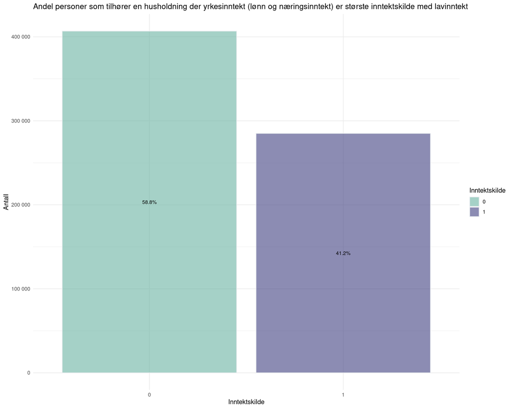

### Tabell: Lavinntekt

Antall personer med yrkesinntekt som den største inntektskilde blant de med lavinntekt

| inntektskilde | Antall personer | Prosentandel |
| --- | --- | --- |
| 0 | 406793 | 58.80092 |
| 1 | 285021 | 41.19908 |

Dersom vi ser bare på innvandrere og norskfødte med innvandrerforeldre, er det flest med yrkesinntekt som den største inntektskilden med 73.2 prosent.

[figure not shown]

### Tabell:

| inntektskilde | Antall personer | Prosentandel |
| --- | --- | --- |
| 0 | 296415 | 26.76293 |
| 1 | 811143 | 73.23707 |

### 2.3.12 Prosentandel av personer der yrkesinntekt er den største inntektskilden som har lavinntekt

Tabellen indikerer at hos personer med yrkesinntekt som utgjør den største inntektskilden, er det innvandrere som har høyest andel lavinntekt.

| Yrkesinntekt som største inntektskilde med lavinntekt Grupper | Yrkesinntekt som største inntektskilde med lavinntekt EU eller EØS status | Yrkesinntekt som største inntektskilde med lavinntekt Totalt antall | Yrkesinntekt som største inntektskilde med lavinntekt Antall lavinntekt | Yrkesinntekt som største inntektskilde med lavinntekt Prosent |
| --- | --- | --- | --- | --- |
| A | NOR | 2772455 | 81576 | 2.94 |
| B | 0 | 390949 | 67024 | 17.14 |
| B | 1 | 360884 | 42721 | 11.84 |
| C | 0 | 40283 | 3849 | 9.55 |
| C | 1 | 5987 | 332 | 5.55 |

## Appendiks

Tabell hvor yrkesinntekt er den største inntektskilden. Jeg har brukt flere uker uten at jeg skjønner hvorfor tallene er så lave.

|  | Hele befolkningen | Hele befolkningen eksludert innvandrerbakgrunn | Innvandrere fra EU/EØS, Nord-Amerika, Australia og New Zealand | Innvandrere fra Afrika, Asia, Latin-Amerika, Europa utenom EU/EØS og Oseania utenom Australia og New Zealand | Norskfødte med innvandrerforeldre fra EU/EØS, Nord-Amerika, Australia og New Zealand | Norskfødte med innvandrerforeldre fra Afrika, Asia, Latin-Amerika, Europa utenom EU/EØS og Oseania utenom Australia og New Zealand |
| --- | --- | --- | --- | --- | --- | --- |
| Yrkesinntekt | 68.980756 | 55.198602 | 6.6155098 | 7.166643 | 0.1097501 | 0.7384439 |
| Lav inntekt med yrkesinntekt | 3.766242 | 3.766242 | 0.7831358 | 1.228644 | 0.0060860 | 0.0705576 |

[^1]: Data hentet fra: Statistisk sentralbyrå (SSB). “Økonomiske analyser - 1/2023.” Tilgjengelig online: [SSB - Økonomiske analyser 1/2023](https://www.ssb.no/nasjonalregnskap-og-konjunkturer/okonomiske-analyser/okonomiske-analyser-1-2023)
[^2]: Data hentet fra: Statistisk sentralbyrå (SSB). “Hvor mange er fattige i Norge?” Tilgjengelig online: [SSB - Hvor mange er fattige i Norge?](https://www.ssb.no/inntekt-og-forbruk/inntekt-og-formue/artikler/hvor-mange-er-fattige-i-norge)